# Reproducible Pitch

January 25, 2016

## Introduction

- Linear regression is the fundamental tool of inferential data science, but its results are often not questioned in an intuitive way
- Expectations aren't often enough assessed before estimation, a point when the data scientist has a less biased mind
- My Shiny app allows users to think about linear regression in an intuitive way by testing their perceived best linear fit of a dataset against that produced by least squares
- This Shiny app can be accessed at: https://erhardmenker.shinyapps.io/courseProject/

## Concept (1)

- For simplicity, my Shiny app sources the built in mtcars dataset and plots the car's weight on the y-axis and corresponding MPG on the x-axis

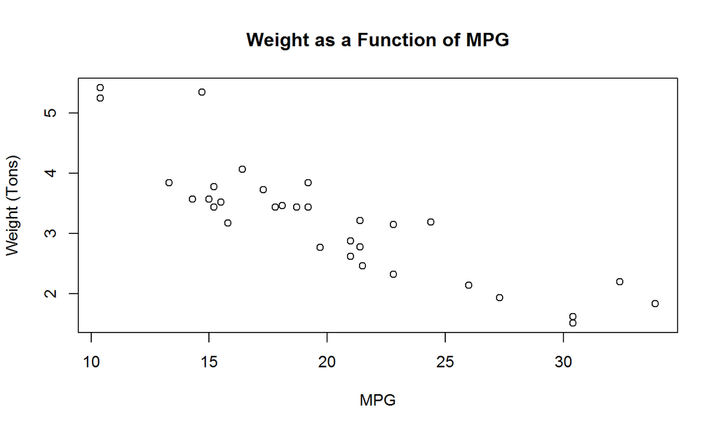

## Concept (2)

- While the best linear line is defined as the one that minimizes the sum of squared errors (pictured below), this app gives the user the ability to look at the data and intuit what the best line could be expected to be (before estimation) and then compared (after estimation)

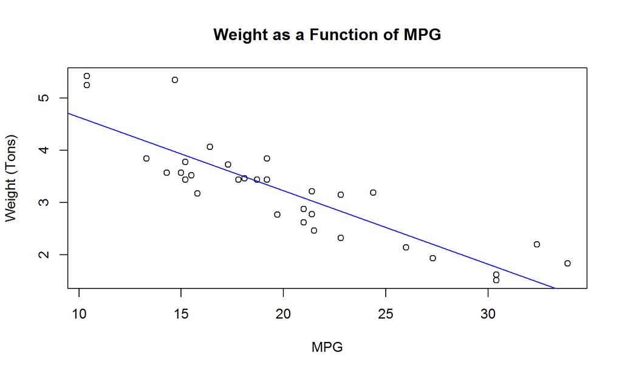